# M45 - Espondilite Ancilosante

```
##
##
## Table: Modelos para ADAL60438_injetavel e suas métricas.
##
## |key                 |.model |metrica |      v.0|       v.12|      v.24|
## |:-------------------|:------|:-------|--------:|----------:|---------:|
## |ADAL60438_injetavel |B      |REQM    | 118.8126|  1254.5284|  1113.100|
## |ADAL60438_injetavel |C      |REQM    |  58.2391|   839.3978|  1234.143|
## |ADAL60438_injetavel |F      |REQM    | 137.5075|  1354.4868|  1347.208|
## |ADAL60438_injetavel |B      |winkler |      NaN| 16866.1607| 17439.190|
## |ADAL60438_injetavel |C      |winkler |      NaN| 13218.0496| 29874.551|
## |ADAL60438_injetavel |F      |winkler |      NaN|  5714.0130| 12288.924|
```

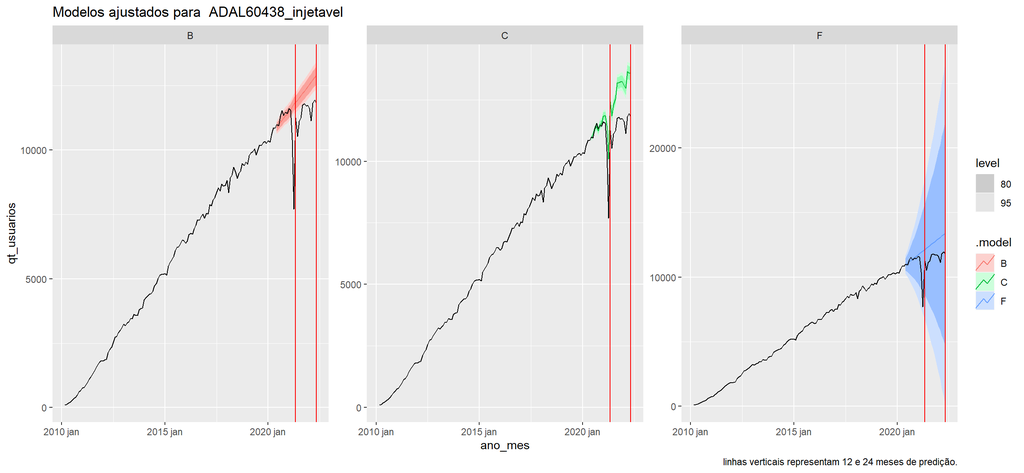

```
##
##
## Table: Modelos para CERT60438_injetavel e suas métricas.
##
## |key                 |.model |metrica |      v.0|       v.12|      v.24|
## |:-------------------|:------|:-------|--------:|----------:|---------:|
## |CERT60438_injetavel |A      |REQM    | 13.18599|   99.30221|  306.6435|
## |CERT60438_injetavel |E      |REQM    | 13.63935|   88.55598|  281.3471|
## |CERT60438_injetavel |F      |REQM    | 22.47226|  134.88341|  383.0839|
## |CERT60438_injetavel |A      |winkler |      NaN|  911.74013| 6418.7451|
## |CERT60438_injetavel |E      |winkler |      NaN| 1331.41015| 7778.3122|
## |CERT60438_injetavel |F      |winkler |      NaN| 1084.65383| 1554.0084|
```

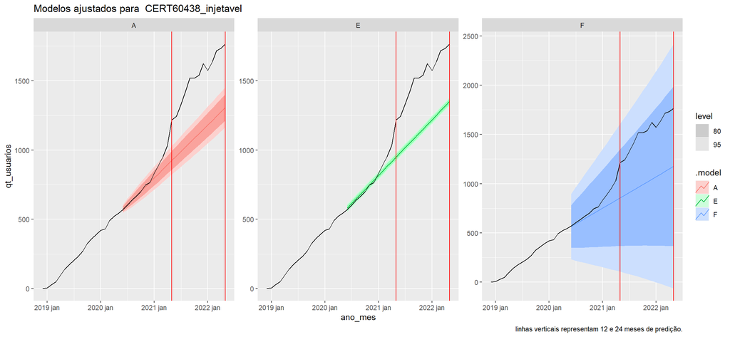

```
##
##
## Table: Modelos para ETAN60438_injetavel e suas métricas.
##
## |key                 |.model |metrica |      v.0|       v.12|       v.24|
## |:-------------------|:------|:-------|--------:|----------:|----------:|
## |ETAN60438_injetavel |B      |REQM    | 98.90395|   114.0968|   165.0482|
## |ETAN60438_injetavel |C      |REQM    | 96.60500|  1438.0615|  2204.2528|
## |ETAN60438_injetavel |E      |REQM    | 99.73883|   137.3684|   223.7739|
## |ETAN60438_injetavel |B      |winkler |      NaN|   940.3453|  1575.9356|
## |ETAN60438_injetavel |C      |winkler |      NaN| 32128.3638| 57346.5146|
## |ETAN60438_injetavel |E      |winkler |      NaN|   879.7289|  1466.5863|
```

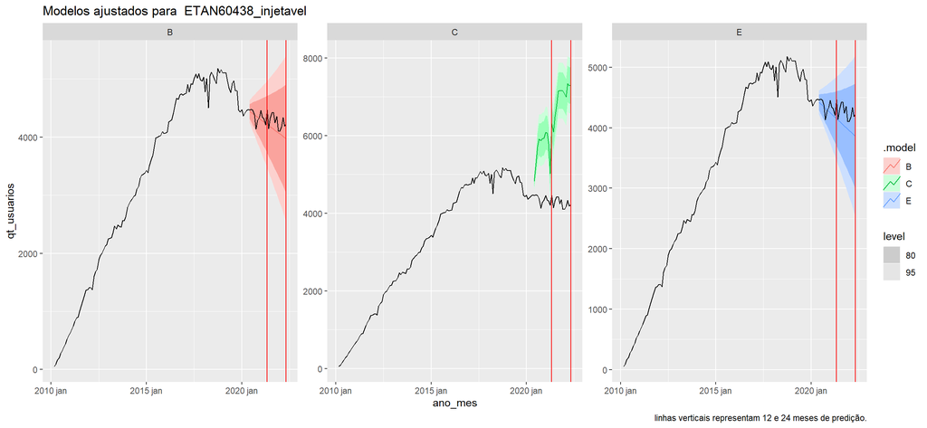

```
##
##
## Table: Modelos para GOLI60438_injetavel e suas métricas.
##
## |key                 |.model |metrica |      v.0|      v.12|      v.24|
## |:-------------------|:------|:-------|--------:|---------:|---------:|
## |GOLI60438_injetavel |A      |REQM    | 35.37547|  167.6979|  388.2193|
## |GOLI60438_injetavel |E      |REQM    | 36.08507|  145.7206|  204.5839|
## |GOLI60438_injetavel |F      |REQM    | 36.75998|  141.5566|  226.3469|
## |GOLI60438_injetavel |A      |winkler |      NaN| 1307.2584| 5535.9604|
## |GOLI60438_injetavel |E      |winkler |      NaN|  469.3108| 1020.4734|
## |GOLI60438_injetavel |F      |winkler |      NaN| 1358.0899| 3041.8353|
```

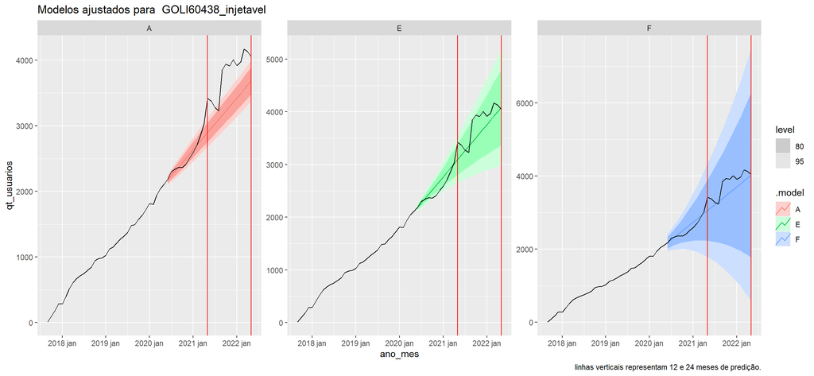

```
##
##
## Table: Modelos para INFL60438_injetavel e suas métricas.
##
## |key                 |.model |metrica |      v.0|      v.12|      v.24|
## |:-------------------|:------|:-------|--------:|---------:|---------:|
## |INFL60438_injetavel |A      |REQM    | 60.59609|  77.17519|  76.24949|
## |INFL60438_injetavel |B      |REQM    | 57.98060|  65.01274|  94.54186|
## |INFL60438_injetavel |C      |REQM    | 45.49639| 144.27242| 218.84062|
## |INFL60438_injetavel |E      |REQM    | 60.78344|  95.42205|  79.13533|
## |INFL60438_injetavel |A      |winkler |      NaN| 441.14281| 588.69984|
## |INFL60438_injetavel |B      |winkler |      NaN| 405.02937| 572.78467|
## |INFL60438_injetavel |C      |winkler |      NaN| 580.48008| 814.64567|
## |INFL60438_injetavel |E      |winkler |      NaN| 382.41077| 481.29854|
```

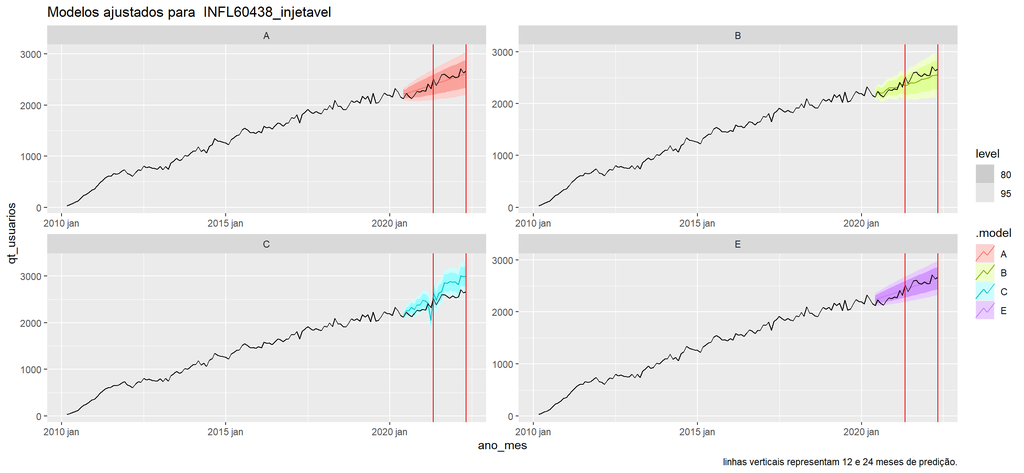

```
##
##
## Table: Modelos para METO60453_injetavel e suas métricas.
##
## |key                 |.model |metrica |      v.0|      v.12|      v.24|
## |:-------------------|:------|:-------|--------:|---------:|---------:|
## |METO60453_injetavel |A      |REQM    | 8.541955|  29.96778|  28.45823|
## |METO60453_injetavel |B      |REQM    | 8.569622|  29.89340|  28.43705|
## |METO60453_injetavel |F      |REQM    | 8.925001|  25.79564|  30.51536|
## |METO60453_injetavel |A      |winkler |      NaN| 124.77368| 148.91759|
## |METO60453_injetavel |B      |winkler |      NaN| 110.86201| 139.92883|
## |METO60453_injetavel |F      |winkler |      NaN| 212.84938| 383.02499|
```

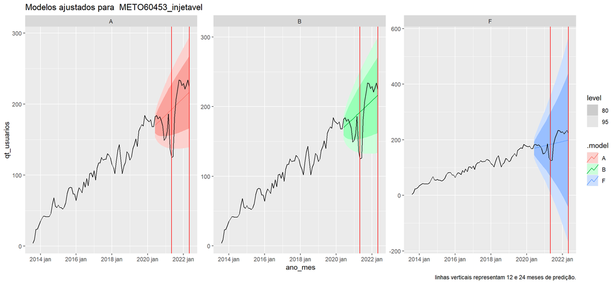

```
##
##
## Table: Modelos para METO60453_oral e suas métricas.
##
## |key            |.model |metrica |      v.0|       v.12|      v.24|
## |:--------------|:------|:-------|--------:|----------:|---------:|
## |METO60453_oral |A      |REQM    | 35.18281|  101.36482|  149.0168|
## |METO60453_oral |C      |REQM    | 29.26052|  111.25252|  118.7575|
## |METO60453_oral |E      |REQM    | 35.03897|   97.86588|  144.9301|
## |METO60453_oral |F      |REQM    | 36.02158|   89.83984|  127.4361|
## |METO60453_oral |A      |winkler |      NaN|  313.93467|  443.2224|
## |METO60453_oral |C      |winkler |      NaN|  817.09109|  943.2662|
## |METO60453_oral |E      |winkler |      NaN|  300.36820|  469.4436|
## |METO60453_oral |F      |winkler |      NaN| 1145.66326| 1888.1104|
```

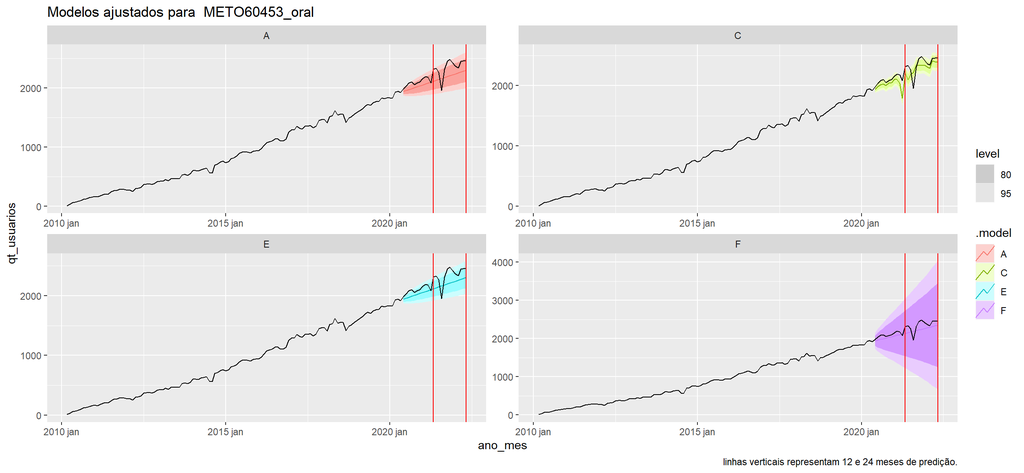

```
##
##
## Table: Modelos para SECU60469_injetavel e suas métricas.
##
## |key                 |.model |metrica |      v.0|      v.12|     v.24|
## |:-------------------|:------|:-------|--------:|---------:|--------:|
## |SECU60469_injetavel |A      |REQM    | 31.40882|  64.67979| 117.2669|
## |SECU60469_injetavel |B      |REQM    | 33.40884|  89.72189| 186.8037|
## |SECU60469_injetavel |A      |winkler |      NaN| 483.34824| 698.4581|
## |SECU60469_injetavel |B      |winkler |      NaN| 408.68130| 637.9242|
```

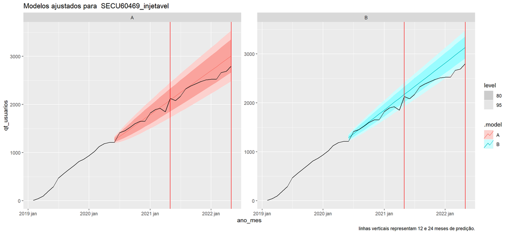

```r
for(i in unique(meds$key)){
  aux <- mm.f.acc %>%
    filter(key == i) %>%
    group_by(key, metrica) %>%
    slice_min(v.0, na_rm = T) %>%
    ungroup() %>%
    union(mm.f.acc %>%
            filter(key == i) %>%
            group_by(key, metrica) %>%
            slice_min(v.12, na_rm = T) %>%
            ungroup()) %>%
    union(mm.f.acc %>%
            filter(key == i) %>%
            group_by(key, metrica) %>%
            slice_min(v.24, na_rm = T) %>% ungroup) %>%
    select(key, .model) %>%
    unique()

  aux %>%
    inner_join(mm.f.acc, by = c("key", ".model")) %>%
    arrange(key, metrica, .model) %>%
    knitr::kable(caption = paste("Modelos para", i, "e suas métricas.")) %>%
    # knitr::kable(caption = paste("Modelos para", i, "e suas métricas."), format = "latex") %>%
    print()

  print(
    meds.cast.24 %>%
      inner_join(aux, by = c("key", ".model")) %>%
      autoplot(meds) +
      facet_wrap( ~ .model, scales = "free") +
      geom_vline(xintercept = as.Date(max(
        meds.treino$ano_mes
      ) + c(12, 24)), colour = "red") +
      labs(title = paste("Modelos ajustados para ", i),
           caption = "linhas verticais representam 12 e 24 meses de predição.")
  )
}
```

Já as tabelas e gráficos acima apresentam somente os modelos com os melhores REQM e escore Winkler. Sendo eles:

### Certolizumabe pegol

Entre os modelos ajustados para certolizumabe pegol, os melhores REQMs foram para os modelos A (ARIMA(1,1,0) w/ drift) e E (Alisamento exponencial linear de Holt). Os valores são próximos para a base de treino (13.18599 e 13.63935, respectivamente) e se distanciam com periodos maiores: 99.30221 e 88.55598 em 12 meses e 306.6435 e 281.3471 para 24 meses. Em relação ao escore Winkler, o modelo F (Alisamento exponencial com erros multiplicativos) tem o melhor escore para 24 meses (1554.0084), mas perde para o modelo A nos 12 primeiros meses preditos. Apesar de parecerem bons modelos para estimar o comportamento para até 12 meses, a presença de menos de 2 anos de dados impede que a modelagem seja satisfatória, esperando-se pelo menos 50 observações para uma boa modelagem usando os modelos propostos. Ainda assim, se usado com cautela, os modelos ainda tem certo valor. Isto posto, o ideal seria um novo ajuste com dados atualizados para o uso dos modelos.

### Etanercepte

Apesar de o modelo C (LM w/ ARIMA(0,0,5)(1,0,0)[12] errors) ter o melhor REQM para a base de treino, suas estimativas para a base de validação são insatisfatórias. Seus REQMs para 12 e 24 meses, respectivamente, são 1438.0615 e 2204.2528, contra 114.0968 e 165.0482 do modelo B (ARIMA(1,2,1)). Este, por sua vez, parece ter capturado satisfatoriamente o comportamento decrescente do número de pacientes para etanercepte, junto com o modelo E (Holt). Ambos têm comportamentos semelhantes no período, um aproximando melhor a média (B) e o outro o fazendo com um intervalo preditivo menor (E). No uso prático dos modelos, seria recomendado utilizar o modelo B, uma vez que se aproximou melhor do comportamento observado e assume uma faixa maior de valores possíveis.

### Golimumabe

Os modelos com melhores ajustes para golimumabe foram ARIMA(1,1,0) w/ drift (A), suavização exponencial de Holt (E) e suavização exponencial com erros multiplicativos (F). Dentre eles, o melhor ajuste para a base de treino foi o A, enquanto para 12 e 24 meses os melhores REQM foram F (141.5566 contra 145.7206 de E) e E (204.5839 contra 226.3469 de F). Para ambos os intervalos (um e dois anos) o modelo E teve escores melhores que as alternativas (469.3108 para 12 meses, seguido por A com 1307.2584; e 1020.4734 para 24 seguido por F com 3041.8353). A análise dos gráficos corrobora com escolha do modelo E para a estimativa dos números de pacientes de golimumabe.

### Infliximabe

Para Infliximabe, quatro modelos tiveram bons ajustes: ARIMA(1,1,0) w/ drift (A), ARIMA(0,1,1)(1,0,0)[12] w/ drift (B), LM w/ ARIMA(2,0,1)(1,0,0)[12] errors (C), e suavização exponencial de Holt (E). Quando avaliados com a base de treino, o melhor REQM foi o do modelo C (45.49639) seguido do B (57.98060). Para 12 meses, o modelo B foi o que atingiu o melhor REQM (65.01274), seguido do A (77.17519) e em 24 meses o A teve o melhor desempenho quanto aos desvios (76.24949), seguido de E (79.13533). Quanto aos escores, o modelo E obteve os melhores escores tanto para 12 quanto para 24 meses (382.41077 e 481.29854, respectivamente) seguido do modelo B (405.02937 e 572.78467). A análise dos gráficos evidencia mais uma vez o bom ajuste dos modelos. Dentre os ajustados, pode-se utilizar qualquer um dos modelos A, B ou E com eficácia similar. Contudo, no uso para tomada de decisão, sugere-se a adoção do modelo A, por ter uma banda de confiança mais ampla e ser mais simples que as alternativas.

### Metotrexato (injetável)

Os modelos ajustados para metotrexato injetável tiveram desempenhos parecidos, com a média dos REQM para a base de teste = 8.678859 e desvio padrão 0.2136133, sendo o modelo A (ARIMA(1,1,0) w/ drift) o menor (8.541955). Em 12 meses o modelo F (suavização exponencial com erros multiplicativos) teve o melhor REQM (25.79564), enquanto A e B (ARIMA(0,1,0) w/ drift) ficaram em média = 29.93059; o cenário se inverteu para 24 meses, em que A e B ficaram em torno de 28.44764 e F passou de 30. Quanto ao escore, o modelo B obteve os melhores escores para os dois periodos: 110.86201 para 12 meses, seguido de 124.77368 para o modelo A; e 139.92883 para 24 seguido também pelo modelo A com 148.91759. Isto posto, bem como a análise dos gráficos, sugere que o modelo B seja o mais recomendado para a predição do número de pacientes de espondilite tratados com metotrexato injetável.

### Metotrexato (oral)

A forma oral de metotrexato teve quatro modelos com bom desempenho. O modelo C (LM w/ ARIMA(1,0,2) errors), contudo, só teve REQMs melhores que as alternativas nos períodos de teste (29.26052) e 24 meses (118.7575). Por outro lado, obteve escores mais altos que os modelos A (ARIMA(1,1,0) w/ drift) e E (suavização exponencial de Holt). Para 12 meses, o modelo F (suavização exponencial com erros multiplicativos) teve o REQM mais baixo (89.83984), seguido de E (97.86588). Por fim, os melhores escores para 12 e 24 meses foram dos modelos E (300.36820) e A (443.2224), respectivamente. O modelo C, apesar de ter bom REQM para 24 meses, depende de informações que não estão disponíveis no momento da predição e teria de recorrer ao uso de uma predição do número total de pacientes no período, aumentando a incerteza. Pela análise da tabela e dos gráficos, conclui-se que tanto o modelo A quanto o E poderiam servir para a predição da série de metotrexato oral. A suavização exponencial de Holt teve métricas melhores que as de A, mas seus desempenhos são próximos o suficiente dada a grandeza dos dados modelados.

### Secuquinumabe

Dada a escassez de dados para secuquinumabe, a modelagem também foi restrita. Ainda que dois modelos tenham sido ajustados, o ideal para a modelagem seria a obtenção de dados mais recentes, totalizando pelo menos 50 observações. Isto posto, o modelo A (ARIMA(1,1,0) w/ drift) estimou melhor a média da série que o modelo B (ARIMA(0,1,0) w/ drift), enquanto este teve melhores escores. Ainda que as métricas apontem para o uso do modelo B, o primeiro modelo contém os dados observados com maior margem, o que é interessante dada a escassez de dados. Reitera-se que há a necessidade de uma nova modelagem utilizando um volume mais expressivo de dados.

```r
save.image(file = "M45.RData")
```

# Conclusões

Sugere-se a adoção do modelo D para a demanda total (exponencial com erros multiplicativos).

Para adalimumabe, prefere-se adotar o modelo B (ARIMA(1,1,1)(1,0,0)[12] w/ drift). Apesar de haver modelos que atingiram métricas melhores durante a análise de resíduos, o modelo B é mais simples que o C (LM com erros ARIMA) e não depende de valores desconhecidos de número total de pacientes.

Os modelos ajustados para certolizumabe pegol podem não ser satisfatórios devido ao curto período disponível para o ajuste. O ideal neste caso seria ajustar os modelos com dados novos a fim de reavaliá-los.

Para etanercepte, tanto o modelo B (ARIMA(1,2,1)) quanto o E (Holt linear) tiveram bons ajustes. Contudo, recomenda-se o uso do modelo B pois este se aproximou melhor dos dados observados e tem um intervalo preditivo mais amplo, abarcando uma gama maior de valores possíveis, o que pode ser vantajoso dada a incerteza inerente ao processo de predição.

O modelo com melhores métricas para a estimativa de golimumabe foi a suavização exponencial de Holt (E). Apesar de um curto período disponível para o treino (somente 32 observações), o modelo E foi capaz de predizer o comportamento nos 24 meses seguintes.

A série de metotrexato oral pode ser estimada tão bem com o modelo E (suavização exponencial de Holt) quanto pelo modelo A (ARIMA(1,1,0) w/ drift). Ambos têm métricas bastante parecidas, principalmente no que se refere a REQMs. Qualquer um dos dois poderia ser utilizado na estimativa da série.

Secuquinumabe tem somente 39 meses de observações nos dados, ainda assim, os melhores modelos ajustados foram A (ARIMA(1,1,0) w/ drift) e B (ARIMA(0,1,0) w/ drift). O modelo preferido entre eles foi o A, por ter intervalo preditivo maior que B, ao mesmo tempo que apresentou melhor ajuste da média. Isto posto, é interessante realizar novos ajustes com maior volume de dados.